# 爬民政部官网_地图数据

李誉辉

2020年2月21日

**简介：**

前面我们爬取民政部官网的行政区域代码，  
这里我们爬取县级地图数据。

# 1 需要的包

```r
rm(list = ls()); gc() # 清空内存
library(tibble)
library(dplyr)
library(purrr)
library(magrittr)
library(sf)
library(stringr)
library(tidyr)
library(readr)
library(ggplot2)
library(rmapshaper) # 拓扑融合行政区域
```

```
##           used (Mb) gc trigger (Mb) max used (Mb)
## Ncells  524652 28.1    1188345 63.5   621320 33.2
## Vcells 1006270  7.7    8388608 64.0  1599914 12.3
```

# 2 行政区域代码

爬取行政区域代码见笔者前面的文章。

```r
file_pre <- "E:/R_input_output/data_input/xian_China"

sheng_shi_xian_code <- read.csv(file = paste(file_pre,
                                             "sheng_shi_xian_code.csv",
                                             sep = "/"),
                                header  = TRUE,
                                stringsAsFactors = FALSE)

# 动态表格展示
DT::datatable(sheng_shi_xian_code)
```

|  | sheng | code_she | shi | code_s | xian | code_x |
| --- | --- | --- | --- | --- | --- | --- |
| 1 | 北京市 | 110000 | 北京市 | 110000 | 东城区 | 110101 |
| 2 | 北京市 | 110000 | 北京市 | 110000 | 西城区 | 110102 |
| 3 | 北京市 | 110000 | 北京市 | 110000 | 朝阳区 | 110105 |
| 4 | 北京市 | 110000 | 北京市 | 110000 | 丰台区 | 110106 |
| 5 | 北京市 | 110000 | 北京市 | 110000 | 石景山区 | 110107 |
| 6 | 北京市 | 110000 | 北京市 | 110000 | 海淀区 | 110108 |
| 7 | 北京市 | 110000 | 北京市 | 110000 | 门头沟区 | 110109 |
| 8 | 北京市 | 110000 | 北京市 | 110000 | 房山区 | 110111 |
| 9 | 北京市 | 110000 | 北京市 | 110000 | 通州区 | 110112 |
| 10 | 北京市 | 110000 | 北京市 | 110000 | 顺义区 | 110113 |

[output cut: 17728 more lines]

# 3 `API`接口

通过Chrome浏览器查看民政部官网的源代码，发送点击请求，  
可以发现服务器返回的`json`格式地图数据。  
`API`前缀都是 `http://xzqh.mca.gov.cn/data/`,

- 获取全国省级地图，则加后缀`quanguo.json`;
- 获取全国县级地图，则加后缀`xian_quanguo.json`;
- 获取部分地区，如某个市的县级地图，则加该行政区域代码，再加`.json`;
- 如果要获取市级地图，需要按遍历行政区域代码获取所有市的地图，然后合并县级区域；
- 全国主要山脉，南海九段线数据，则加后缀`quanguo_Line.geojson`;
- **注：**县级地图数据不包括香港和澳门特别行政区，市级地图数据不包括台湾省。

# 4 市内县级数据

这里我们以获取成都市县级地图为例。

## 4.1 获取`json`数据

```r
# 筛选成都市行政区域代码
code_chengdu <- sheng_shi_xian_code %>%
  filter(sheng == "四川省" & shi == "成都市") %>%
  mutate(code = as.character(code_x),
         code_s2 = as.character(code_s)) %>%
  select(shi, code_s = code_s2, xian, code)
head(code_chengdu)

# API前缀
API_pre <- "http://xzqh.mca.gov.cn/data/"

# 通过API获取成都市县级地图数据
mapdata_chengdu <- sf::st_read(dsn = paste0(API_pre,
                                            unique(code_chengdu$code_s),
                                            ".json"),
                               stringsAsFactors=FALSE)
```

|  | shi | code_s | xian | code |
| --- | --- | --- | --- | --- |
| 1 | 成都市 | 510100 | 锦江区 | 510104 |
| 2 | 成都市 | 510100 | 青羊区 | 510105 |
| 3 | 成都市 | 510100 | 金牛区 | 510106 |
| 4 | 成都市 | 510100 | 武侯区 | 510107 |
| 5 | 成都市 | 510100 | 成华区 | 510108 |
| 6 | 成都市 | 510100 | 龙泉驿区 | 510112 |

## 4.2 数据处理

包括筛选数据，去除毗邻行政区域的数据。  
计算行政区域质心坐标。

```r
# 筛选数据
mapdata_chengdu %<>% select(-id, -FillColor) %>%
  rename(code = QUHUADAIMA, name = NAME) %>%
  filter(code %in% code_chengdu$code)

# 计算行政区域质心坐标
centerPoints_chengdu <- mapdata_chengdu %>% select(-name) %>%
  # 计算行政区域质心坐标
  st_centroid() %>%
  left_join(code_chengdu, by = "code") %>%
  select(-shi, -code_s)
```

## 4.3 画图

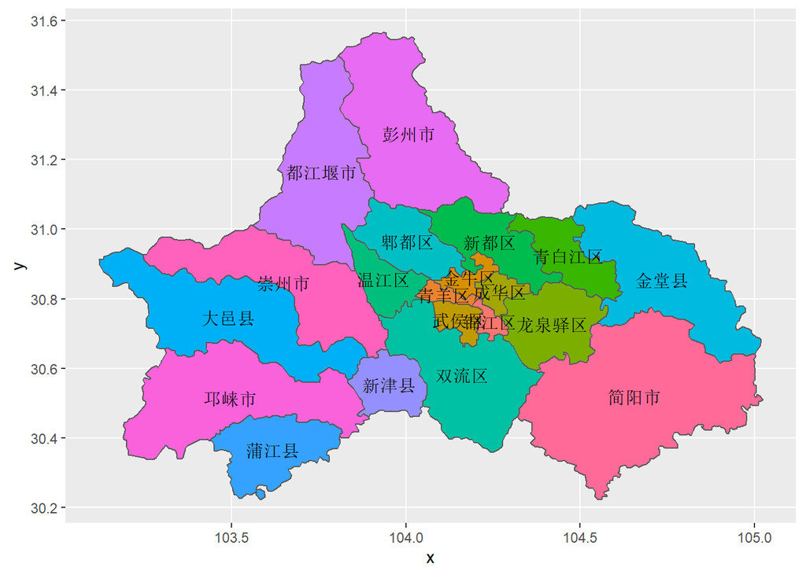

```r
ggplot(mapdata_chengdu) +
  geom_sf(aes(fill = code), show.legend = FALSE) + #
  geom_sf_text(data = centerPoints_chengdu, aes(label = xian),
               color = "black") +
  coord_sf()
```

## 4.4 业务数据

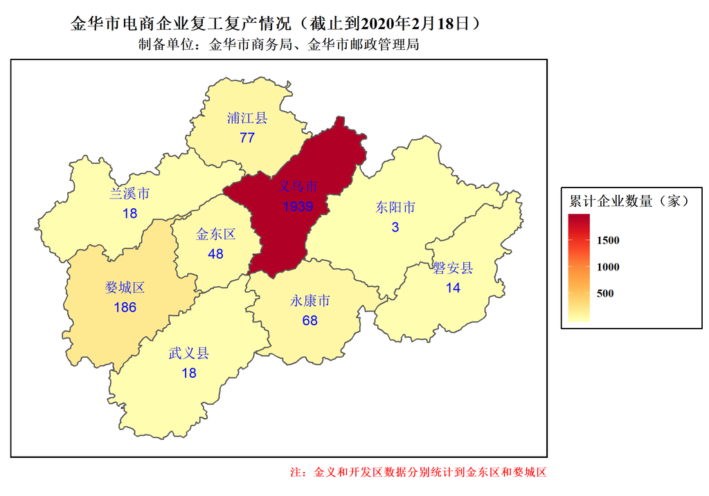

# 5 省内市级数据

这里我们首先获取省内各个市的县级数据，  
然后熔化掉市内县级行政区域的边界线，  
就得到省内市级数据。如果需要省内县级数据，则不进行边界线熔化这一步。

## 5.1 自定义函数

```r
# 筛选四川省行政区域代码
code_sichuan <- sheng_shi_xian_code %>%
  filter(sheng == "四川省") %>%
  mutate(code_s2 = as.character(code_she),
         code_s3 = as.character(code_s),
         code = as.character(code_x)) %>%
  select(sheng, code_she = code_s2, shi, code_s = code_s3, xian, code_x = code)
head(code_sichuan)



# 自定义一个函数，获取每个市的县级地图数据
get_xian <- function(code_s, code_range){
  data_sf <- sf::st_read(dsn = paste0(API_pre, code_s, ".json"),
                         stringsAsFactors=FALSE) %>%
    select(xian = NAME, code_x = QUHUADAIMA, geometry) %>%
    filter(code_x %in% code_range)
  return(data_sf)
}
```

|  | sheng | code_she | shi | code_s | xian | code_x |
| --- | --- | --- | --- | --- | --- | --- |
| 1 | 四川省 | 510000 | 成都市 | 510100 | 锦江区 | 510104 |
| 2 | 四川省 | 510000 | 成都市 | 510100 | 青羊区 | 510105 |
| 3 | 四川省 | 510000 | 成都市 | 510100 | 金牛区 | 510106 |
| 4 | 四川省 | 510000 | 成都市 | 510100 | 武侯区 | 510107 |
| 5 | 四川省 | 510000 | 成都市 | 510100 | 成华区 | 510108 |
| 6 | 四川省 | 510000 | 成都市 | 510100 | 龙泉驿区 | 510112 |

## 5.2 获取`json`数据

通过`map`函数遍历所有省内市的`json`数据。  
然后进行熔化掉市内县级行政区的边界线。

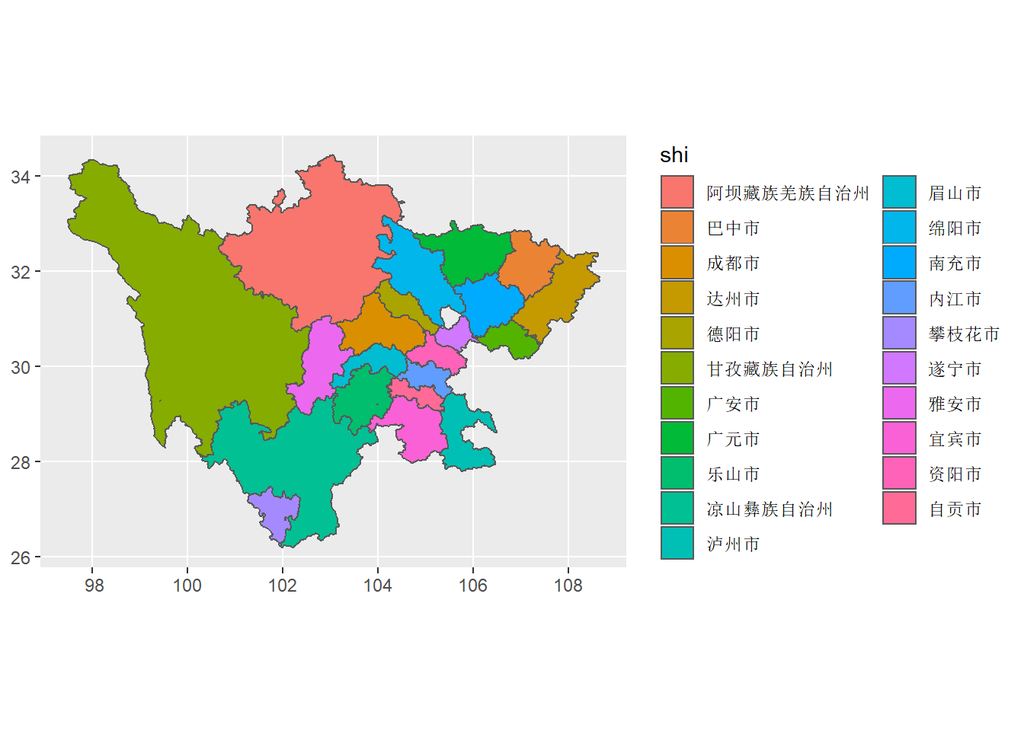

```r
# 获取四川省县级地图数据
code_sichuan2 <- code_sichuan %>%
  select(shi, code_s) %>% distinct(code_s, .keep_all = TRUE)

mapdata_sichuan <- code_sichuan %>%
  select(code_s, code_x) %>%
  group_nest(code_s) %>%
  left_join(code_sichuan2, by = "code_s") %>%
  mutate(., code_range = map(.$data, ~.x$code_x)) %>%
  select(shi, code_s, code_range) %>%
  # 获取json地图数据
  mutate(., xian_sf = map2(.x = .$code_s, .y = .$code_range,
                           ~get_xian(.x, .y))) %>%

  mutate(., xian_sf2 = map(.$xian_sf, ~select(.x, -xian))) %>%
  select(shi, code_s, xian_sf2) %>%
  # 熔化市内县级行政区的边界线
  mutate(., data = map(.$xian_sf2, ~ms_dissolve(.x))) %>%
  mutate(., shi_sf = map(.$data, ~.x$geometry)) %>%
  select(shi, code_s, shi_sf)

# 合并sfc
mapdata_sichuan2 <- mapdata_sichuan$shi_sf %>%
  purrr::reduce(., c) %>%
  st_set_geometry(select(mapdata_sichuan, -shi_sf), .)
ggplot(mapdata_sichuan2) +
  geom_sf(aes(fill = shi)) +
  coord_sf()
```

## 5.3 计算质心坐标

```r
# 计算行政区域质心坐标
centerPoints_sichuan <- mapdata_sichuan2 %>% select(-shi) %>%
  # 计算行政区域质心坐标
  st_centroid() %>%
  left_join(code_sichuan2, by = "code_s") %>%
  select(shi, code_s, geometry)
```

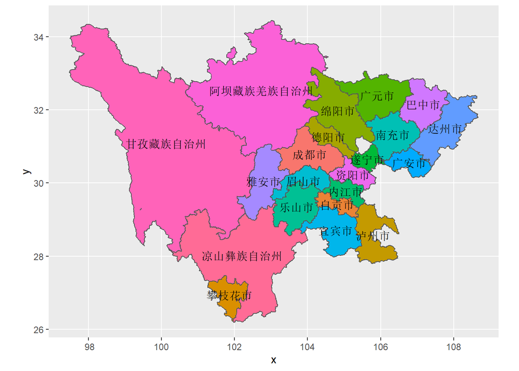

```r
ggplot(mapdata_sichuan2) +
  geom_sf(aes(fill = code_s), show.legend = FALSE) +
  geom_sf_text(data = centerPoints_sichuan, aes(label = shi),
               color = "black") +
  coord_sf()
```

# 6 全国县级地图数据

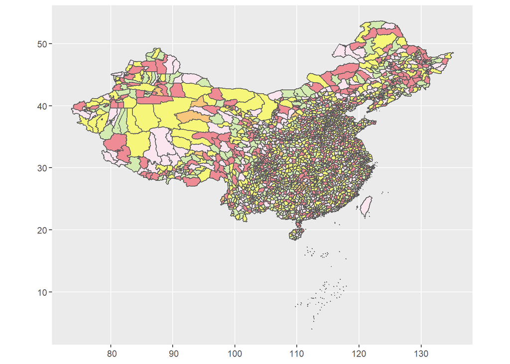

```r
xian_quanguo <- sf::st_read(dsn = paste0(API_pre, "xian_quanguo.json"),
                               stringsAsFactors=FALSE)

ggplot(xian_quanguo) +
  geom_sf(aes(fill = QUHUADAIMA), show.legend = FALSE) +
  coord_sf() +
  scale_fill_manual(values = xian_quanguo$FillColor,
                    labels = xian_quanguo$QUHUADAIMA)
```

**参考来源：**

- 中国县级地图绘制
- [全国行政区划信息查询平台](http://xzqh.mca.gov.cn/map)
- 浙江行政区域代码表格
- [2019年12月中华人民共和国县以上行政区划代码](http://www.mca.gov.cn/article/sj/xzqh/2019/2019/202002191838.html)
- [百度地图坐标拾取系统](http://api.map.baidu.com/lbsapi/getpoint/index.html)
- [计算行政区域中心坐标](https://gis.stackexchange.com/questions/43543/how-to-calculate-polygon-centroids-in-r-for-non-contiguous-shapes)
- [行合并sf对象](https://rdrr.io/cran/sf/man/bind.html)
- [高德地图API接口获取经纬度坐标](https://mp.weixin.qq.com/s/2DawZWjlT1jxbs7GM0DLVg)
- [Geocomputation with R](https://geocompr.robinlovelace.net/spatial-operations.html)
- [rmapshaper包github](https://github.com/ateucher/rmapshaper)